Life on the road · Practical guides by Steve English

VanLifers · Practical guide to campervan connectivity

# Campervan Wi-Fi Basics: What’s Out There and Why It Matters

Phone hotspot, MiFi, aerials, routers and multi-network SIMs explained — with practical examples for real vanlife.

Steve English · VanLifers guide · Updated 9 November 2026 · Approximately 12 minutes

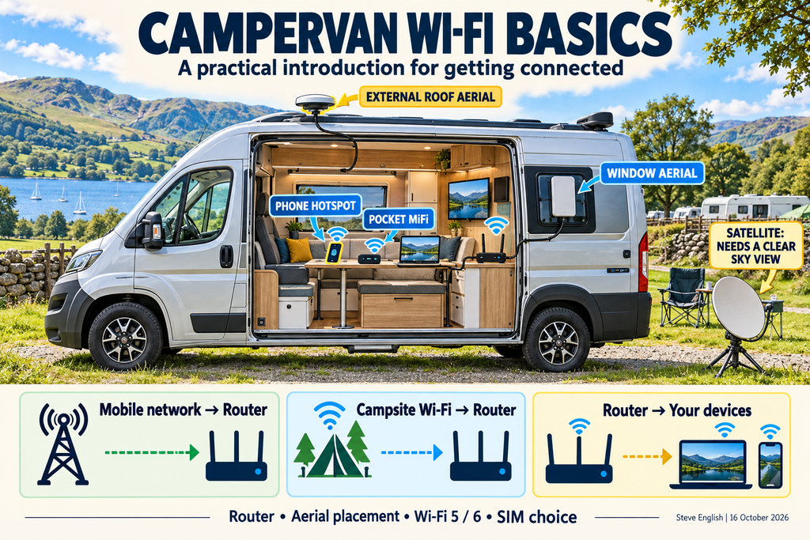

The main options at a glance. The illustration is an overview, not an installation or wiring diagram.

Ask about internet in a campervan group and you’ll hear plenty of different answers. Someone gets everything they need from their mobile phone. Someone else swears by a roof aerial. Another wouldn’t travel without Starlink.

They may all have chosen something that suits them. The difficulty is knowing which arrangement will suit **your van, where you park and what you want to do online**.

You don’t need to understand every technical specification before buying. But understanding the main types of equipment—and the differences between them—can save you buying something that doesn’t solve your problem.

## 1. Start with the metal box you’re sitting in

A metal-bodied van can weaken radio signals passing between equipment inside and networks outside. You’ll often hear this called the **Faraday cage effect**.

Your van isn’t a perfectly sealed laboratory cage: windows, openings and its construction all affect reception. Nevertheless, metal panels and foil-backed insulation can make getting a usable connection indoors harder.

That helps explain why your mobile phone might work outside, then struggle once you take it inside and close the doors.

Before spending anything, try the same device outside, inside and beside different windows. If its connection improves noticeably outside, that tells you something useful about the problem you’re trying to solve.

## 2. “Wi-Fi” can mean three different parts of the setup

People often say “the Wi-Fi is rubbish” when the problem is somewhere else.

For a typical campervan arrangement, there are three connections to understand:

| Connection | What it does |
| --- | --- |
| **Mobile-network connection** | Brings internet to your phone, MiFi or SIM router through a mobile network. |
| **Campsite Wi-Fi connection** | Provides an alternative internet source, if your equipment can connect to and share it. |
| **Wi-Fi inside your van** | Connects your TV, laptop and mobile phones to your router or hotspot. |

You can have a strong Wi-Fi connection between your laptop and router while the router itself has a poor connection to the internet.

Equally, a good mobile connection doesn’t guarantee that a badly positioned router will provide good Wi-Fi throughout a large vehicle.

The equipment needs to do the job required at each stage.

## 3. Using your mobile phone as a hotspot

A phone hotspot is often the easiest place to start. Your phone connects to its mobile network, then shares that connection with your laptop, television or other devices.

For occasional use, it may be all you need. There’s no separate router to buy, install or power.

The compromises are practical. Running a hotspot uses battery power, the phone can become warm, and anyone remaining in the van loses that connection when you take the phone away.

The phone is also receiving its mobile signal from wherever you’ve left it. If that’s inside a metal cupboard—or simply inside a van that weakens the signal—it may struggle.

**A hotspot is a useful option. It just isn’t automatically the right permanent arrangement for everyone.**

## 4. Pocket MiFi devices

A pocket MiFi is a small mobile router with its own SIM and, usually, a rechargeable battery. It receives mobile internet and creates a Wi-Fi hotspot for your other devices.

Think of it as giving the hotspot job to a separate little box.

It can be useful when you want to leave internet running in the van while taking your phone out, avoid using your phone’s battery, or carry a shared connection with you while walking or travelling.

Check the battery life, supported mobile networks and number of connected devices. Some models also accept external aerials; others rely entirely on their built-in aerials.

The limitation remains the same: **a MiFi left inside the van still has to receive its mobile signal through the vehicle’s body**. Moving it near a suitable window may help, but portability alone doesn’t overcome poor reception.

**VanLifers example: TravelBuddy pocket MiFi**

If you want a separate hotspot without installing a router, Anvil's TravelBuddy is a portable 4G MiFi with a pay-as-you-go multi-network SIM. The published package includes 1GB starter data and supports up to five devices. It's a practical option for occasional trips, not a replacement for a carefully installed external aerial in challenging locations.

[See the TravelBuddy MiFi and current details](https://anvilmobile.com/solutions/vanlife-motorhomes)

## 5. SIM routers: what are you paying for?

A SIM router provides a more permanent connection for the van. Depending on the model, it can offer external aerial connections, wired Ethernet sockets, multiple SIM options and settings for switching between internet sources.

There’s a substantial range between basic consumer equipment and industrial or vehicle-focused models.

For a campervan, useful things to check include:

- **Power requirements:** whether it accepts your supply voltage and what protection or adapter it needs.
- **Operating temperature:** the manufacturer’s actual limits, especially for equipment left inside a hot vehicle.
- **Mounting and vibration suitability:** whether it is intended for mobile installations.
- **Aerial connections:** which are for mobile reception, which are for Wi-Fi, and how many are provided.
- **Internet-source switching:** whether it can use campsite Wi-Fi and fall back to mobile data.
- **Mobile capabilities:** supported frequency bands, 4G or 5G, and aerial configuration.

An industrial label isn’t a promise that something will last forever. It should point you towards specifications you can check.

Likewise, a more expensive router doesn’t necessarily provide a better connection in every location. Its capabilities need to match your aerials, network and intended use.

### Wi-Fi 5 and Wi-Fi 6

These describe the Wi-Fi connection between the router and your devices. **They are different from 4G and 5G**, which describe the mobile-network connection bringing internet to the router.

Wi-Fi 6 is newer than Wi-Fi 5 and can offer improvements in speed and handling several compatible devices. Your devices also need to support the relevant features to benefit fully.

For a van with several people streaming, working and using connected equipment, that may be worth considering. For lighter use, Wi-Fi 5 may be perfectly adequate.

**Wi-Fi 6 cannot turn a weak mobile-network connection into fast internet.** It improves one part of the system.

**VanLifers examples: from a basic installed kit to 5G**

Anvil's **Essential Kit** is built around the Teltonika RUT200 4G router, with window/desk or roof-aerial choices. For heavier use, the **Nomad Pro** uses the GL.iNet GL-X3000 5G router with Wi-Fi 6, while the **Gold Standard** features a Teltonika RUTX50 5G router. Choosing between them should depend on how you use the connection, the vehicle and your budget — not just the highest advertised speed.

[Compare the VanLifers kit options](https://anvilmobile.com/solutions/vanlife-motorhomes)

## 6. Aerial placement: inside, at the window or outside?

A router with aerials attached directly to it is still receiving from inside the vehicle. Getting the receiving aerial into a better position can make a substantial difference.

There are several ways to do that.

### Window or desk aerials

These connect to a compatible router and can be positioned beside or against a window, away from some of the metal surrounding the router.

They appeal to people who want a straightforward installation without drilling the roof. Some can also be moved around to find a better position.

Results depend on the aerial, glass, surrounding bodywork and signal conditions. A window aerial is an option worth understanding—not a guaranteed improvement in every installation.

### Temporary external aerials

An aerial can be placed outside when parked, using an appropriate suction mount, magnetic base, bracket or other fixing.

That gets it outside the metal body without necessarily committing to a permanent installation.

You do have to put it out and bring it in, secure it against weather, and route the cable without crushing it in a window or door. Magnetic mounts need a suitable magnetic surface; they won’t stick directly to aluminium or fibreglass.

Some aerials also require a particular mounting surface to perform as intended. Check the instructions rather than assuming any convenient position will do.

### Permanent roof aerials

A permanent roof aerial gives you an outside installation that’s ready whenever you need it. Many campervan installations use a compact puck containing several aerial elements.

Installation commonly involves a roof penetration, mounting hardware and a properly sealed cable entry. The exact method depends on the product and roof.

It’s a convenient arrangement for frequent use, but placement still matters. Roof equipment can obstruct or interfere with an aerial, and unnecessarily long or unsuitable cables can reduce the benefit.

**The aim is a suitable aerial, correctly installed in a good position—not simply the largest puck or highest price.**

**Matching the aerial to the setup**

VanLifers' Essential Kit offers a choice of window/desk or roof mounting; the larger 5G kits list multi-element roof aerials. Check the complete router-and-aerial configuration, especially whether outside campsite Wi-Fi reception is important to you.

[See the aerial choices in the packages](https://anvilmobile.com/solutions/vanlife-motorhomes)

## 7. What’s actually inside a roof puck?

Two similar-looking pucks can contain quite different equipment.

One may contain only mobile-network aerial elements. Another may combine mobile, Wi-Fi and GPS elements in the same housing.

Those elements serve different purposes:

| Element | Its job |
| --- | --- |
| **Mobile / cellular** | Connects the router to mobile networks. |
| **Wi-Fi** | Connects to the router’s Wi-Fi radio connections; its role depends on the router’s configuration. |
| **GPS / GNSS** | Receives positioning signals where the router supports that function. |

A “7-in-1” description might mean **four mobile elements, two Wi-Fi elements and one positioning element**. Check the actual breakdown: it doesn’t mean seven aerials all improving your mobile internet.

### What do 2×2 and 4×4 MIMO mean?

In basic terms, MIMO allows compatible equipment to use multiple aerial paths together.

You’ll encounter configurations such as **2×2 MIMO** and **4×4 MIMO**. These matter because the router and aerial arrangement should match.

A router designed to use four mobile aerial connections won’t receive the full intended external aerial arrangement if you connect only two. Equally, a four-element mobile aerial won’t turn a two-connection router into a four-connection model.

More aerial paths can help compatible equipment under suitable conditions. They don’t guarantee twice the speed: the network, signal quality and other factors still matter.

### Can it pick up campsite Wi-Fi?

This is a separate question from whether the router creates Wi-Fi inside your van.

To use campsite Wi-Fi as an internet source, the **router must support that function**. If you want roof-mounted reception for it, the aerial must also have suitable Wi-Fi elements connected to the right sockets.

A mobile-only roof puck doesn’t necessarily prevent a router using campsite Wi-Fi through its own Wi-Fi aerials. It means that puck isn’t providing the outside Wi-Fi reception.

Before buying, ask:

**“Can this complete setup receive campsite Wi-Fi from outside the van and share it inside?”**

Also remember that better reception cannot fix a campsite internet connection that is overloaded or slow.

## 8. SIM cards: choosing the connection behind the equipment

The hardware matters, but so does the SIM inside it.

A single-network SIM may offer excellent value where that provider has good coverage. The difficulty for travellers is that the best network at one stop may be poor at the next.

Check the places you actually visit. A nationwide reputation is less useful than knowing whether you can connect where you regularly park.

### Dual-SIM routers

Some routers accept two SIMs and can switch between them under specified conditions.

That can provide an alternative when one connection fails. Check how switching works: **dual SIM does not automatically mean both connections are used together**, or that the router constantly chooses whichever is fastest.

### Cross-network, or open-network, SIMs

Cross-network SIMs—sometimes described as open-network or multi-network SIMs—can access more than one permitted mobile network.

That can be attractive when travelling because it reduces reliance on a single provider.

However, the wording needs checking. Ask which networks are available, how selection works, what triggers a change, and whether switching interrupts the connection.

Don’t assume every multi-network product continually compares all networks and switches seamlessly to the strongest or fastest one.

Payment arrangements also vary. Cross-network access doesn’t automatically mean pay-as-you-go, unlimited data or unrestricted overseas use.

### How much data do you need?

Messages, email and ordinary browsing generally need less data than regular video streaming.

Television streaming, large game downloads, software updates and cloud gaming can consume substantial amounts. Ordinary online gameplay is a different workload from downloading or streaming an entire game.

An unlimited plan may suit heavy use, but check the terms: overseas allowances, fair-use limits and permitted router use may differ from the headline offer.

For occasional trips, a smaller allowance or flexible top-up arrangement may be more suitable. Look at your usage before committing.

**Why a multi-network SIM matters on the road**

The VanLifers TravelBuddy SIM is advertised for use across **EE, O2, Three and Vodafone**, with pay-as-you-go data top-ups. That offers more network options as you move around Britain, though actual availability and switching depend on signal and service conditions. To explore likely coverage before travelling, try our [interactive four-network coverage map](https://vanlifer-anvil.github.io/coverage-map/).

[Explore VanLifers SIMs and packages](https://anvilmobile.com/solutions/vanlife-motorhomes)

## 9. Where does Starlink fit?

Starlink brings internet through satellites rather than a mobile network. It can be a very useful option in remote places where mobile coverage is poor but there is a suitable view of the sky.

Trees, buildings and other obstructions can interrupt that view and affect service. That makes the exact parking spot important: neither “countryside” nor “town” tells you enough on its own. Starlink recommends checking the proposed position for obstructions. [1]

There isn’t one sensible blanket answer to whether it costs more or less. Compare the equipment, current plan, power requirements and data usage against the mobile arrangement you would otherwise buy.

Some travellers choose mobile internet. Some choose satellite. Some use both to cover different situations.

And the television and streaming services people use through Starlink can also run through a suitable mobile-data connection. The satellite equipment isn’t what supplies the programmes—it supplies the internet connection.

## 10. Television and streaming in the van

A compatible smart TV can connect directly to your van’s Wi-Fi. Alternatively, a streaming stick or box can connect to a suitable television and provide access to supported apps.

Those apps then use whichever internet connection your router is sharing: mobile data, campsite Wi-Fi or satellite.

Before buying a streaming device, check:

- Which apps it actually supports.
- Whether subscriptions are required.
- Its power supply and television connections.
- Any regional or overseas viewing restrictions.
- Whether downloads for offline viewing are supported on that particular device and app.

Freeview through a television aerial is a different route and doesn’t use your internet data allowance for ordinary broadcast viewing. Streaming gives you another option, but it does use data.

Combined television and mobile aerial products also exist. As with roof pucks, check what each product genuinely includes rather than assuming one housing provides every type of reception.

## What makes sense for your van?

Start with what you need to do.

If your phone hotspot already meets your needs, you may not need anything else. If you want a separate portable connection, a pocket MiFi may suit you.

If reception worsens inside the van, investigate aerial placement and a compatible router. If you travel frequently, permanent outside equipment may offer worthwhile convenience. If you regularly stop beyond useful mobile coverage, satellite becomes a different option to consider.

The useful questions are straightforward:

**Where does the internet come from? Where is the receiving aerial? What can the router do? And what does the SIM or satellite plan actually include?**

Once you have those answers, the various boxes, pucks and packages become much easier to compare.

Steve English

### Find the right connection for your van

Start with what you actually need: occasional hotspot access, a permanently installed 4G system, or a 5G setup for full-time travel and remote work. VanLifers offers TravelBuddy MiFi, Essential, Nomad Pro and Gold Standard options, with the router, aerial and SIM matched as a kit.

[Explore the VanLifers range at Anvil Mobile](https://anvilmobile.com/solutions/vanlife-motorhomes) · [Compare mobile coverage on the map](https://vanlifer-anvil.github.io/coverage-map/)

## Sources & further reading

1. Starlink: checking for obstructions.  
   https://starlink.com/np/support/article/bcbf0078-be81-d345-4bce-ebbcfa196f56
2. Teltonika: caravan internet, router features and external aerial connections.  
   https://www.teltonika-networks.com/newsroom/how-to-improve-caravan-internet-with-5g-connectivity
3. Teltonika: an example of configurable SIM-switching conditions (RUT950).  
   https://wiki.teltonika-networks.com/view/RUT950_Mobile

This guide is an introduction, not a report of independent performance tests. VanLifers package details reflect Anvil’s published information on 9 November 2026; confirm current specifications, prices, compatibility and terms before ordering. Network coverage is predicted rather than guaranteed.